# SAM morphometry: estimation statistics with dabestr

Fausto Rodriguez

May 14, 2026

# Purpose

Apply estimation statistics (DABEST, Ho et al. 2019) to the same SAM morphometry data analysed parametrically in `SAM_morphology_analysis.Rmd`. For each of the four SAM traits (height, radius, $h/r$, $h/r^2$), report the mean difference Inv4m $-$ CTRL with bootstrap 95% confidence intervals via the multi two-group estimation idiom (`dabestr`). Effect sizes are not $p$-thresholded; significance is read from whether the bootstrap CI overlaps zero.

# 1. Libraries and data

```r
library(tidyverse)
library(dabestr)
library(cowplot)
library(knitr)

sam_raw <- read.csv(
  here("data", "MeristemMesurements_B73-INV_December2024.csv")) %>%
  dplyr::select(-starts_with("X")) %>%
  mutate(
    radius       = Width / 2,
    hr_ratio     = Height / radius,
    shape_factor = 1000 * Height / (radius^2),
    genotype = factor(case_when(Genotype == "INV" ~ "Inv4m",
                                Genotype == "B73" ~ "CTRL",
                                TRUE              ~ as.character(Genotype)),
                      levels = c("CTRL", "Inv4m"))
  )

cat("rows:", nrow(sam_raw), "\n")
```

```
## rows: 38
```

```r
sam_raw %>% count(genotype)
```

```
##   genotype  n
## 1     CTRL 18
## 2    Inv4m 20
```

# 2. Per-trait dabest analyses

`dabestr::load()` builds a dabest object; `mean_diff()` computes the unpaired mean difference with 5000 bootstrap resamples (defaults). The returned object carries the bootstrap distribution, point estimate, and 95% CI.

```r
sam_traits <- c("Height", "radius", "hr_ratio", "shape_factor")
trait_units <- c(Height       = "Height (μm)",
                 radius       = "Radius (μm)",
                 hr_ratio     = "h / r",
                 shape_factor = expression(h / r^2 ~ "(nm"^{-1}*")"))

run_dabest <- function(tr) {
  d <- sam_raw %>% dplyr::select(genotype, !!sym(tr)) %>%
    rename(value = !!sym(tr)) %>%
    dplyr::filter(!is.na(value))
  dabest_obj <- dabestr::load(d, x = genotype, y = value,
                              idx = c("CTRL", "Inv4m"))
  mean_diff(dabest_obj)
}

dabest_results <- setNames(lapply(sam_traits, run_dabest), sam_traits)
```

# 3. Effect size summary

```r
summary_tbl <- lapply(sam_traits, function(tr) {
  bs <- dabest_results[[tr]]$boot_result
  tibble(trait        = tr,
         mean_diff    = bs$difference[1],
         ci_lo_95     = bs$bca_ci_low[1],
         ci_hi_95     = bs$bca_ci_high[1],
         ci_overlap_0 = (bs$bca_ci_low[1] <= 0) & (bs$bca_ci_high[1] >= 0))
}) %>% bind_rows()

knitr::kable(summary_tbl, digits = 3,
             caption = paste("Mean differences (Inv4m - CTRL) with",
                             "bootstrap 95% BCa intervals."))
```

Mean differences (Inv4m - CTRL) with bootstrap 95% BCa intervals.

| trait | mean_diff | ci_lo_95 | ci_hi_95 | ci_overlap_0 |
| --- | --- | --- | --- | --- |
| Height | 9.652 | -1.311 | 19.926 | TRUE |
| radius | 0.031 | -2.012 | 2.474 | TRUE |
| hr_ratio | 0.158 | -0.002 | 0.282 | TRUE |
| shape_factor | 2.494 | 0.104 | 4.476 | FALSE |

```r
write_csv(summary_tbl,
          file.path(paths$intermediate,
                    "SAM_dabestr_mean_diff_BCa.csv"))
```

# 4. Estimation plots

```
##
##
## ### Height — Height (μm)
```

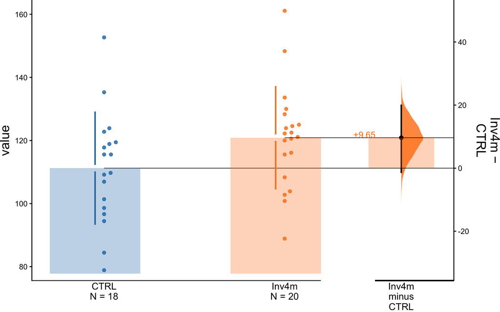

```
##
##
## ### radius — Radius (μm)
```

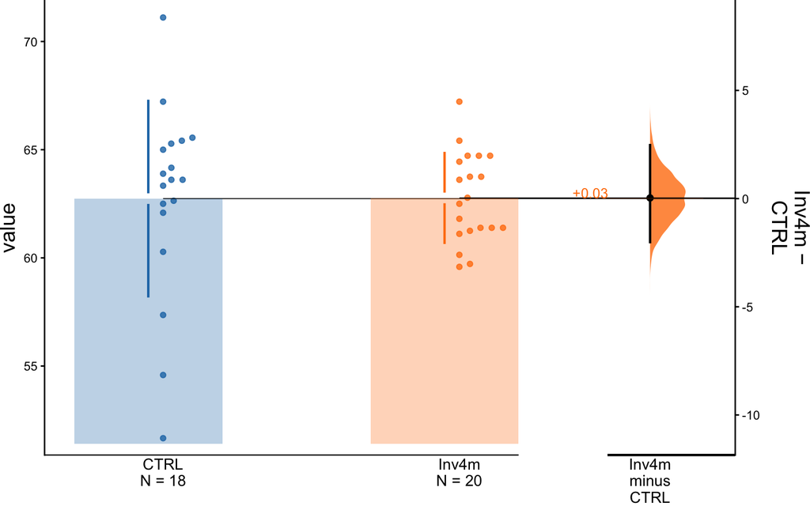

```
##
##
## ### hr_ratio — h / r
```

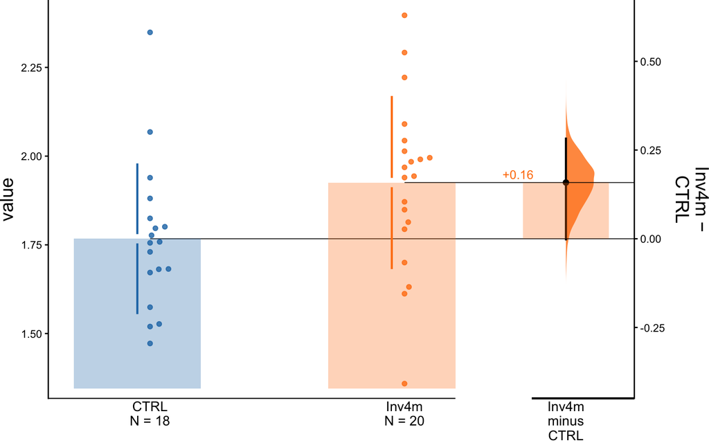

```
##
##
## ### shape_factor — ~h/r^2"(nm"^{
##     -1
## } * ")"
```

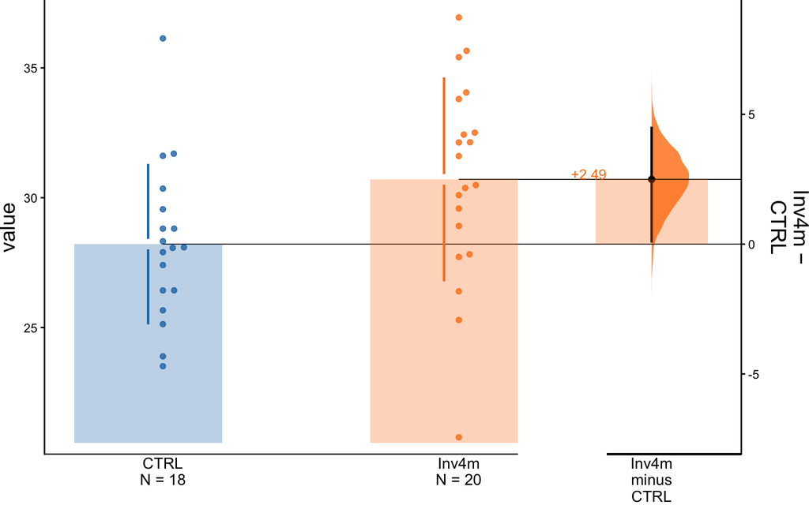

```r
plot_list <- setNames(
  lapply(sam_traits, function(tr) {
    dabest_plot(dabest_results[[tr]],
                raw_marker_alpha = 0.8,
                contrast_label   = paste("Inv4m −\nCTRL"))
  }),
  sam_traits
)

for (tr in sam_traits) {
  cat("\n\n### ", tr, " — ", as.character(trait_units[[tr]]), "\n\n", sep = "")
  print(plot_list[[tr]])
}
```

# 5. Composite grid (all four traits)

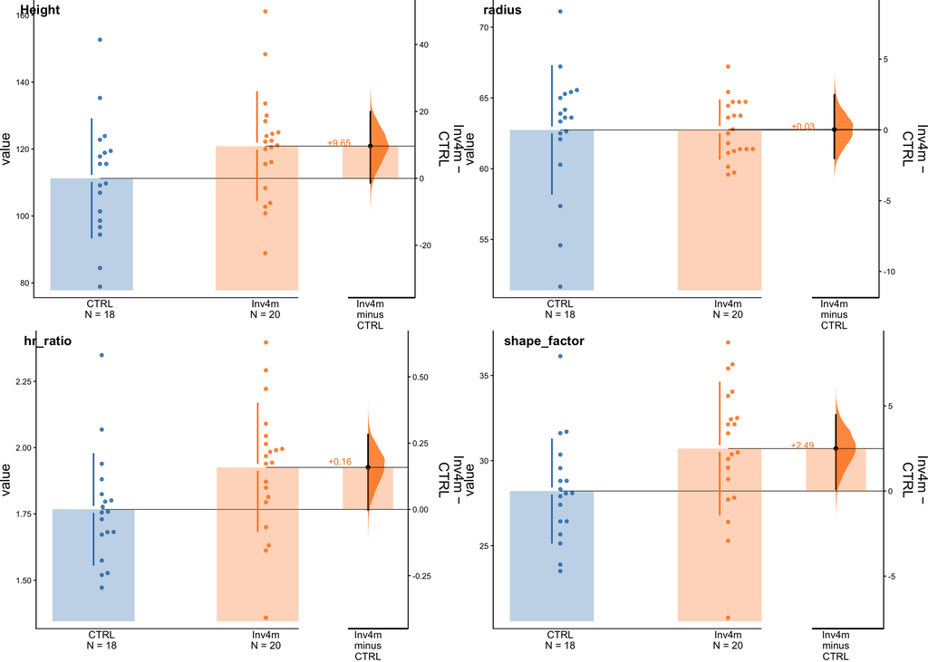

```r
grid_plot <- cowplot::plot_grid(
  plot_list$Height,
  plot_list$radius,
  plot_list$hr_ratio,
  plot_list$shape_factor,
  nrow = 2, ncol = 2,
  labels = sam_traits,
  label_size = 14, label_fontface = "bold"
)

print(grid_plot)
```

```r
ggsave(file.path(paths$figures, "SAM_dabestr_estimation_plots.png"),
       grid_plot, width = 14, height = 10, dpi = 200, bg = "white")
cat("\nSaved:",
    file.path(paths$figures, "SAM_dabestr_estimation_plots.png"), "\n")
```

```
##
## Saved: /Users/fvrodriguez/Library/CloudStorage/GoogleDrive-frodrig4@ncsu.edu/My Drive/repos/inv4m/results/inversion_paper/figures/SAM_dabestr_estimation_plots.png
```

# 6. Interpretation notes

- Whisker bars in each contrast panel are bias-corrected and accelerated (BCa) bootstrap 95% confidence intervals on the mean difference.
- A trait is conventionally “significant at $\alpha = 0.05$” under this framework if its 95% CI does not cross zero. This is conceptually similar to a two-sided test at $\alpha = 0.05$ but does not require an FDR correction across traits since the inference target is the per-trait effect size and CI rather than a global null-hypothesis test.
- The CI half-widths report inferential precision and are interpretable on the natural scale of each trait.